# PSL (S21) Coding Assignment 2

### 02/05/2021

```python
import pandas as pd
import numpy as np
import matplotlib.pyplot as plt
from sklearn import datasets
```

## Load Data

You can ignore the code snippet below and start your code with loading the csv file “Coding2_myData.csv” provided on Piazza.

```python
myData = datasets.load_boston()
X = myData.data
y = myData.target.reshape(-1,1)
var_names = myData.feature_names
y = np.log(y)
X[:, [0, 2, 4, 5, 7, 8, 9]] = np.log(X[:, [0, 2, 4, 5, 7, 8, 9]])
X[:, 1] = X[:, 1]/10
X[:, 6] = X[:, 6]**2.5 / 10**4
X[:, 10] = np.exp(0.4*X[:, 10])/1000
X[:, 11] = X[:, 11]/100
X[:, 12] = X[:, 12] ** 0.5
```

```python
X.shape, len(y)
```

```
((506, 13), 506)
```

```python
var_names
```

```
array(['CRIM', 'ZN', 'INDUS', 'CHAS', 'NOX', 'RM', 'AGE', 'DIS', 'RAD',
       'TAX', 'PTRATIO', 'B', 'LSTAT'], dtype='<U7')
```

## CD for Lasso

Implement the Coordinate Descent algorithm for Lasso. You are allowed to use `numpy` and `sklearn`, although the code below does not use `sklearn`; some students may want to use `sklearn.preprocessing.StandardScaler` for standardization.

Some part of the function MyLasso is blocked here, but your submission should include all code used to produce your results.

```python
def MyLasso(X, y, lam_seq, maxit = 500):

    # X: n-by-p design matrix without the intercept
    # y: n-by-1 response vector
    # lam_seq: sequence of lambda values
    # maxit: number of updates for each lambda

    # Center/Scale X
    # Center y

    n, p = X.shape
    nlam = len(lam_seq)

    ##############################
    # YOUR CODE:
    # Record the corresponding means and scales
    # For example,
    # y_mean = mean of y
    # Xs = centered and scaled X
    ##############################


    # Initilize coef vector b and residual vector r
    b = np.zeros(p)
    r = y
    B = np.zeros((nlam, p + 1))

    # Triple nested loop
    for m in range(nlam):
        lam = 2 * n * lam_seq[m]
        for step in range(maxit):
            for j in range(p):
                Xs_j = Xs[:, j].reshape(-1,1)
                r = r + Xs_j * b[j]
                b[j] = one_var_lasso(r, Xs_j, lam)
                r = r - Xs_j * b[j]
        B[m, 1:] = b

    ##############################
    # YOUR CODE:
    # Scale back the coefficients;
    # Update the intercepts stored in B[, 1]
    ##############################

    return(B.T)
```

## Some Technical Details

- We use the following function to solve the Lasso estimate for $\beta_j$ given other coefficients fixed; see the derivation in Coding2.pdf.

```python
def one_var_lasso(r, x, lam):
    # the code is written with r, x being n-by-1 vectors
    xx = x.T @ x
    xr = x.T @ r
    b = (abs(xr) - lam/2)/xx
    if b < 0:
        b = 0
    b = np.sign(xr) * b
    return(b)
```

- Why we need to scale the lambda value by (2n) in `lam = 2*n*lam.seq[m]`? As detailed in Coding2.pdf, the `one_var_lasso` function is derived based on objective function
  $$\text{RSS} + \lambda \cdot | \beta|,$$
  while the objective function used in `glmnet` is
  $$\frac{1}{2n} \text{RSS} + \lambda | \beta| \ \propto \ \text{RSS} + 2 n \lambda | \cdot \beta|$$
  So to compare results from the two algorithms on an equal footing, we need to scale our lambda value by (2n).
- Note that `glmnet` standardizes the data using a definition of “standard deviation” with "n" in the denominator, which corresponds to the default setting of `numpy.std` with `ddof = 0`. So different from the R sample code, we do not need to scale the standard deviation returned by `numpy.std`.

## Test Your Code

Test your code with the following lambda sequence. If you want to use `np.logspace`, please change the base to be `e`; the default setting is 10.

The 80 sets of coefficients (including the intercept) are stored in a 14-by-80 matrix `myout`.

```python
log_lam_seq = np.linspace(-1, -8, num = 80)
lam_seq = np.exp(log_lam_seq)
myout = MyLasso(X, y, lam_seq, maxit = 100)
```

```python
myout.shape
log_lam_seq.shape, tmp.shape
```

```
((80,), (14, 80))
```

Produce the path plot for the 13 non-intercept coefficients with the x-coordinate to be the lambda values in log-scale.

```
(-8.35, -0.6499999999999999, -0.3099945835136132, 0.49974219884846643)
```

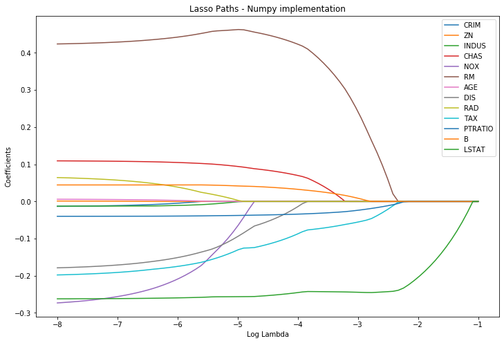

```python
p, _ = myout.shape
plt.figure(figsize = (12,8))

for i in range(p-1):
    plt.plot(log_lam_seq, myout[i+1, :], label = var_names[i])

plt.xlabel('Log Lambda')
plt.ylabel('Coefficients')
plt.title('Lasso Paths - Numpy implementation')
plt.legend()
plt.axis('tight')
```

## Check the Accuracy

Compare the accuracy of your algorithm against the output from `glmnet`. The maximum difference between the two coefficient matrices should be less than 0.005.

```python
%cd ~/mydoc/Course/datamining/s21/Rcode
lasso_coef = np.genfromtxt("Coding2_lasso_coefs.csv", delimiter=',',
                           skip_header=1)
lasso_coef.shape
```

```
/Users/feng_macpro/Box/Dolphin/Course/datamining/s21/Rcode
```

```
(14, 80)
```

```python
abs(myout - lasso_coef).max()
```

```
0.004645317400838955
```